# PiGx-BSseq: Differential Methylation Report

BIMSB Bioinformatics Platform

2022-06-25 16:22:48

# 1 Description

PiGx BSseq performs differential methylation testing using *methylKit’s* ,`calculateDiffMeth()` function and produces this report. The report includes tables and figures summarizing similarities and differences between comparison groups as specified in the settings file.

[output not shown]

# 2 Quality Control

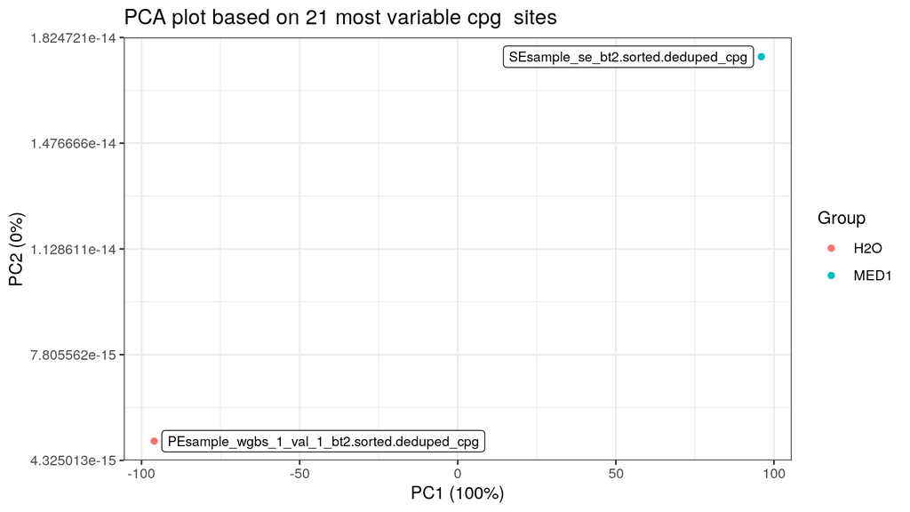

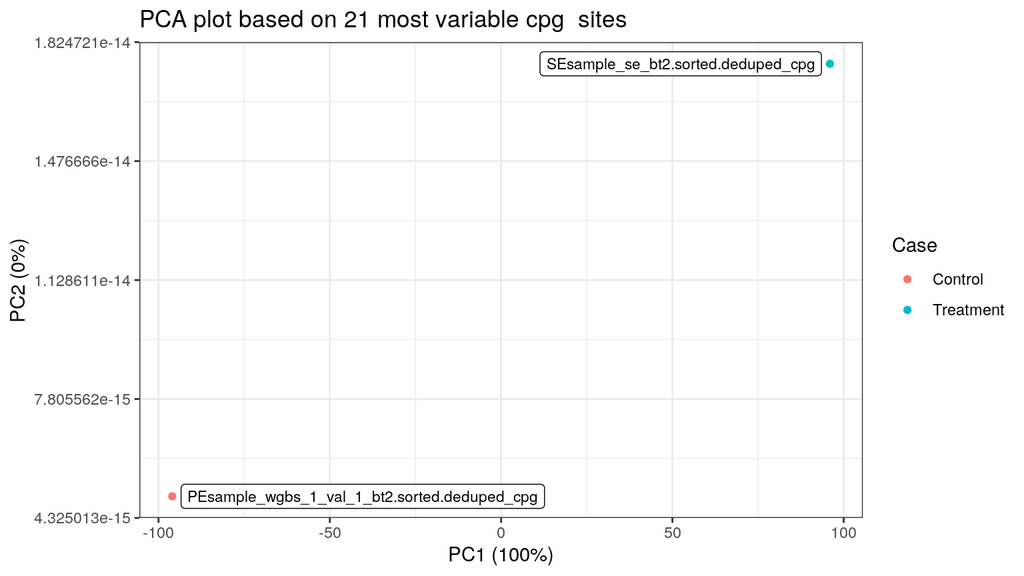

# 3 Differential Methylation Analysis

## 3.1 Calling Differentially Methylated Cytosines

After q-value calculation, differentially methylated bases are extracted based on q-value and percent methylation difference cutoffs. Here we select bases that have q-value < 0.01 and percent methylation difference larger than 25%. Furthermore, we calculate hyper-methylated or hypo-methylated bases.

Overdispersion occurs when there is more variability in the data than assumed by the distribution and is here included in the differentially methylatation calculation.

For more details about `calculateDiffMeth()` and `getMethylDiff()` functions see [methylKit](https://bioconductor.org/packages/release/bioc/html/methylKit.html) and for details about the logistic regression and overdispersion see [Wreczycka, et al (2017)](https://www.sciencedirect.com/science/article/pii/S0168165617315936).

The full table of methylKit calculateDiffMeth() results can be found at:

- **methylKit calculateDiffMeth results file**: /home/data/t020329/ngs/new_meth/results/09_differential_methylation/med1vsh2o/methylDiff_med1vsh2o_cpg_destranded_methylKit_results.tsv

```
## Remapping Treatments Descriptions into treatment and control groups.
```

```
## Control group (0): H2O
```

```
## Treatment group (1): MED1
```

```
##
## **We found  11  cytosines to be differentially methylated .**
```

### 3.1.1 Export Differentially Methylated Cytosines

We export differentially-methylated CpG sites (DMC) to a *BED* file; it can be loaded into a genome browser such as [IGV](http://software.broadinstitute.org/software/igv/) or [UCSC](https://genome.ucsc.edu/) to allow for further analysis, annotation and visualisation.

- **DmC BED file**: /home/data/t020329/ngs/new_meth/results/Reports/med1vsh2o/med1vsh2o_cpg_destranded_methylKit.dmc.bed

## 3.2 Finding Regions of Differential Methylation

We use the `methSeg()` function to perform an unsupervised segmentation of the methylation differences calculated from `calculateDiffMeth()`. Then we classify hyper and hypo methylated segments based on the methylation difference threshold and join neighbouring segments with the same class. For details about the segmentation see [Wreczycka, et al (2017)](https://www.sciencedirect.com/science/article/pii/S0168165617315936). To aggregate the region level statistics we use Stouffer’s weighted Z-method as done by methcp, for details see [Gong and Purdom (2018)](https://www.biorxiv.org/content/10.1101/265116v2).

```
##
## **The segments belong only to a single class,
##  This could indicate the unsupervised clustering of the  segments was not successful or the difference in methylation  is not high enough.**
```

# 4 Annotation of Differential Methylation

## 4.1 Annotation of Differentially Methylated Cytosines

Once differentially-methylated CpG sites (DMC) have been found, the sites are classified into hyper- and hypo-methylated sites, based on two cutoffs: the minimal methylation difference and the qvalue cutoff as shown in the parameter table. Hypermethylation indicates increasingly-methylated sites, while hypomethylation indicates lowered methylation when performing the comparison of treatment - control.

### 4.1.1 Overview of Hyper- and Hypo-Methylated CpGs Over the Genome

This chromosome ideogram represents differential methylation, where only CpGs fulfilling the cutoffs of q-value < 0.01 and methylation difference of at least 25 % are shown.

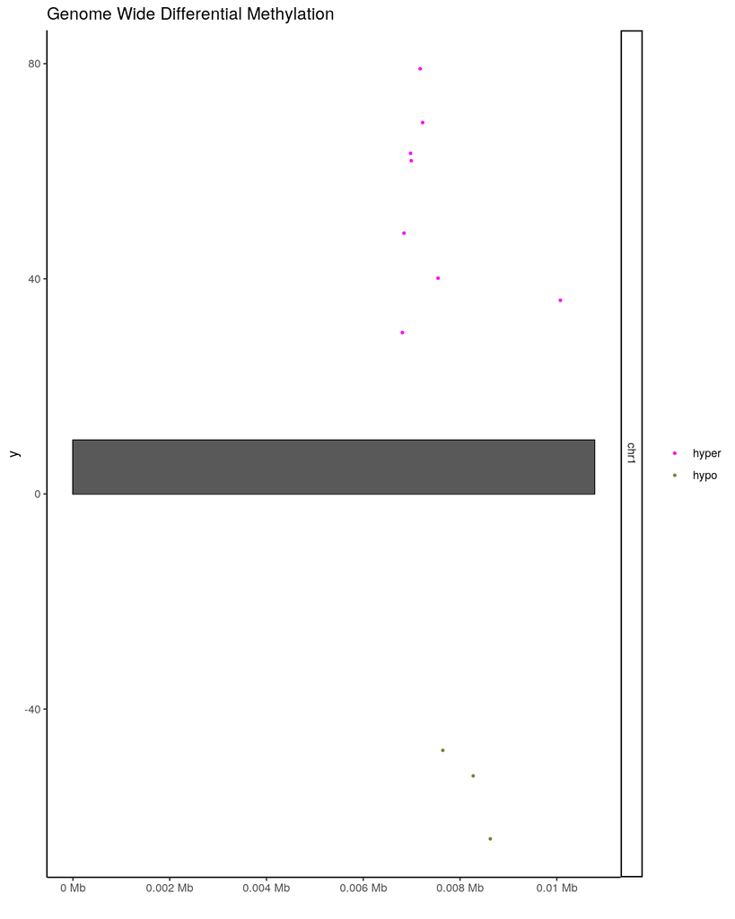

#### 4.1.1.1 Fraction of Differentially Methylated Cytosines per Chromosome

These stacked barplots visualize the percentages of hyper and hypomethylated DMCs out of all covered CpGs for each chromosome.

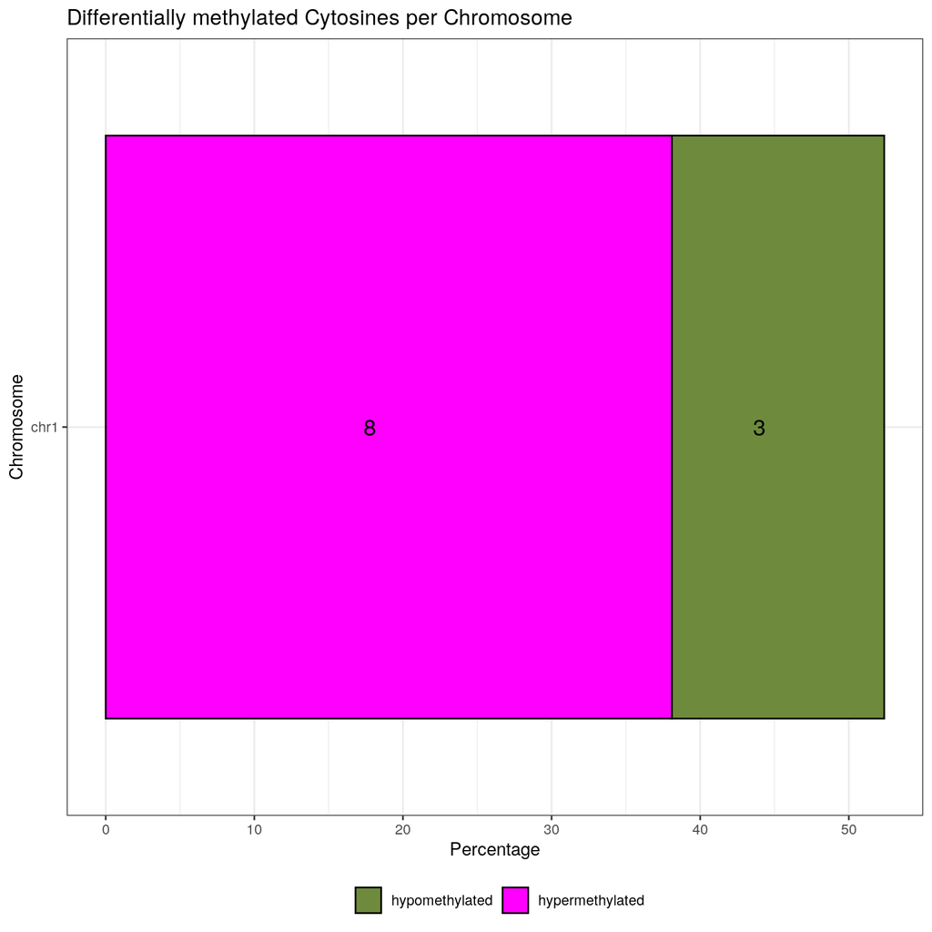

These stacked barplots visualize the percentages of hyper and hypomethylated DMCs out of all detected differential CpGs for each chromosome.

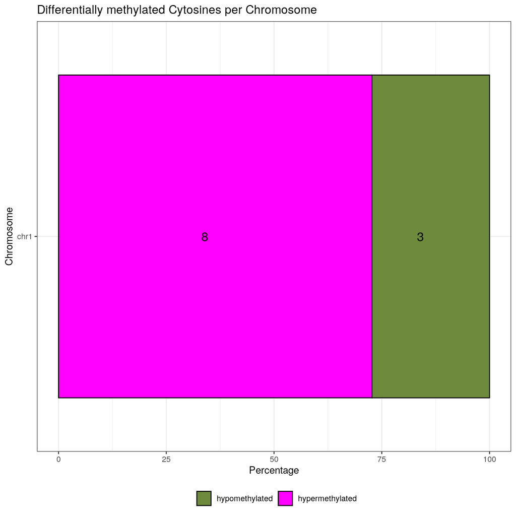